# HW5

2022-11-16

#1

```r
poke_data <- read.csv("Pokemon.csv")

poke_data<-clean_names(poke_data)
```

The clean names function took the column names and turned them lowercase as well as turned periods into underscores.

#2

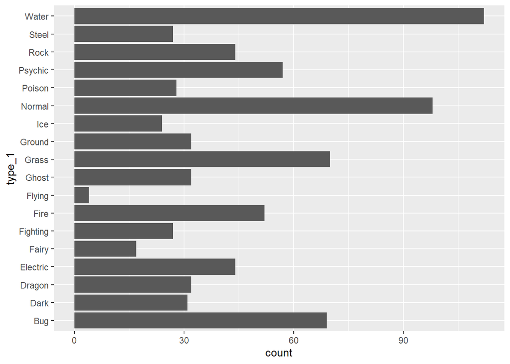

```r
pokebar <- ggplot(poke_data, aes(y=type_1)) + geom_bar()

pokebar
```

```r
poke_data_f <-subset(poke_data,type_1 %in% c("Bug","Fire","Grass","Normal","Water","Psychic"))

poke_data_f$type_1 <- as.factor(poke_data_f$type_1)

poke_data_f$legendary <-as.factor(poke_data_f$legendary)
```

#3

```r
set.seed(6688)
poke_data_split <- initial_split(poke_data_f, prop=.7, strata = type_1)

poke_train <- training(poke_data_split)
poke_test <- testing(poke_data_split)

#318 training observations
count(poke_train)
```

```
##     n
## 1 318
```

```r
# 140 testing observations
count(poke_test)
```

```
##     n
## 1 140
```

```r
poke_folds <- vfold_cv(poke_train, v = 5, stata = type_1)
```

There are multiple categorical outcomes so it is important to stratify again to get accurate cross validation.

#4

```r
poke_re <- recipe(type_1 ~ legendary + generation+sp_atk+attack+speed+defense+hp+sp_def, data = poke_train) %>% step_dummy(c(legendary,generation)) %>% step_normalize(all_numeric_predictors())
```

#5

```r
mix_spec <-
  multinom_reg(penalty = tune(), mixture = tune()) %>%
  set_mode("classification") %>%
  set_engine("glmnet")

poke_wf <- workflow( ) %>% add_recipe(poke_re) %>% add_model(mix_spec)

tune_grid <- grid_regular(penalty(c(-5,5)),mixture(c(0,1)),levels = 10)
```

#6

```r
tune_res <- tune_grid(poke_wf, resamples = poke_folds, grid = tune_grid)
#save(tune_res, file = "tune_res.rda")
```

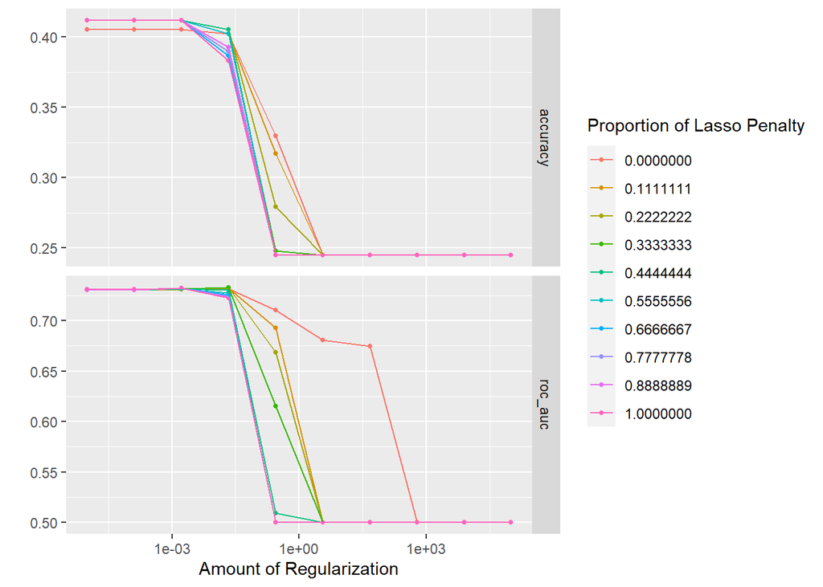

```r
load(file = "tune_res.rda")

autoplot(tune_res)
```

it appears that small values of penalty and large values of mixture produce the best results on accuracy and ROC curve.

#7

```r
best_tune <- select_best(tune_res,metric ='roc_auc')

poke_wf_final <- finalize_workflow(poke_wf,best_tune)

poke_final_fit <- fit(poke_wf_final, poke_train)
pred_res <- augment(poke_final_fit, poke_test)

accuracy(pred_res,truth= type_1, estimate = .pred_class)
```

```
## # A tibble: 1 × 3
##   .metric  .estimator .estimate
##   <chr>    <chr>          <dbl>
## 1 accuracy multiclass     0.364
```

Our multinomial regression model predicted Pokemon with 36.43% accuracy, if values were evenly randomly assigned, we would expect only 16.66% accuracy.

#8

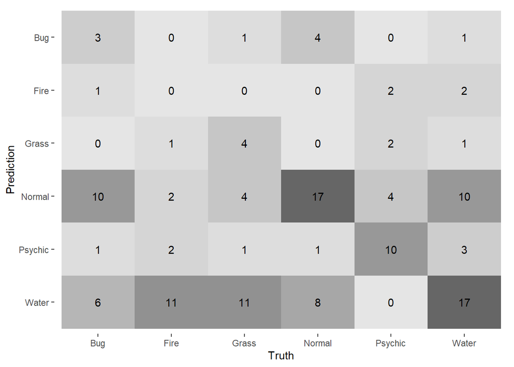

```r
conf_mat(pred_res,truth = type_1, estimate = .pred_class) %>% autoplot(type = 'heatmap')
```

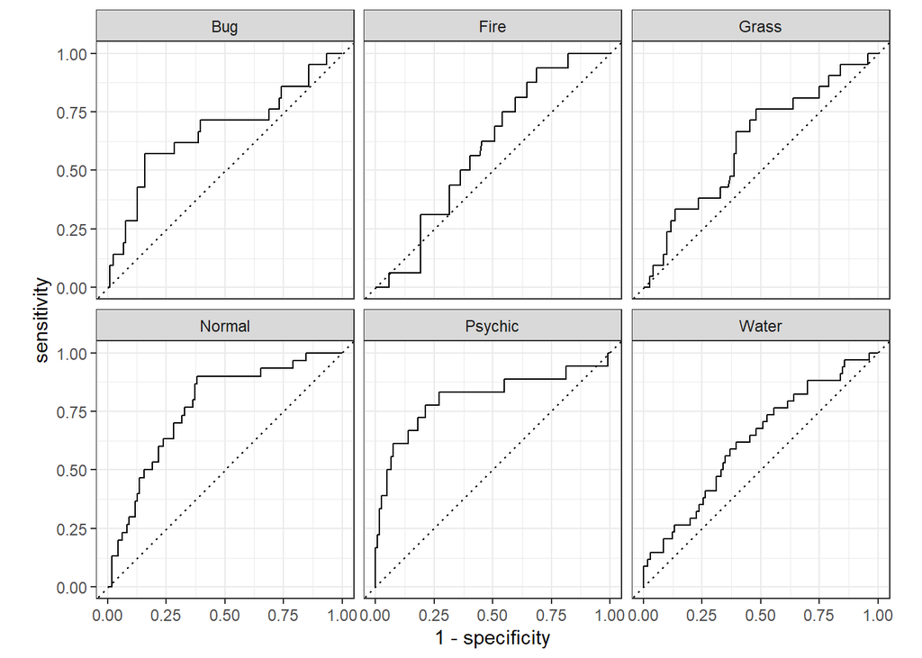

```r
roc_curve(pred_res, truth = type_1, estimate = .pred_Bug:.pred_Water) %>% autoplot()
```

```r
roc_auc(pred_res, truth = type_1, estimate= .pred_Bug:.pred_Water)
```

```
## # A tibble: 1 × 3
##   .metric .estimator .estimate
##   <chr>   <chr>          <dbl>
## 1 roc_auc hand_till      0.682
```

our overall area under the ROC_curve is .6820. Our model does fairly well predicting Psychic and Normal types fairly well, it does marginally worse on bug and grass types and is not very good at distinguishing water and fire types. The model seems to guess water type if it doesn’t know and that may be bringing the ROC curve on water type down.